# Lab 2

Dijia Tang

11/13/2019

```r
library(tidyverse)
```

## The Data

Continue using the annual exective compensation file:

```r
link <- read_csv("http://www3.nd.edu/~sberry5/data/anncomp.csv")
```

As noted in the lecture notes, this data needs some cleaning. You will notice that people are listed multiple times within this data, since it is yearly data – we are just going to deal with that as it is right now. While there are better ways to handle this, it is a lecture for another time. Another issue is that we might not have data from the same year for everyone. Again, multiple ways of dealing with it – we could convert all of the nominal dollars to real dollars (using the Consumer Price Index). This would be the best way to deal with that issue.

```r
library(rvest)
cpiTable <- read_html("https://www.usinflationcalculator.com/inflation/consumer-price-index-and-annual-percent-changes-from-1913-to-2008/") %>%
  html_table(header = TRUE) %>%
  `[[`(1)
names(cpiTable) <- as.character(cpiTable[1,])
cpiTable = cpiTable[-1,]
```

After a little row/name clean-up, we can join the cpiTable into our compensation data and create an inflation-adjusted total salary variable.

The formula to convert nominal dollars to real dollars is $\frac{\text{nominal}}{\text{price index} / 100}$

*The compensation would make more sense if they are in hundreds.*

```r
compensation <- merge(cpiTable,link,by.x='Year',by.y='YEAR')
compen_selected <- compensation %>%
  select(Year,Avg,SALARY,TOTAL_CURR,AGE,GENDER) %>%
  mutate(Year=as.integer(Year), Avg=as.numeric(Avg),SALARY = as.numeric(SALARY)*100,TOTAL_CURR=as.numeric(TOTAL_CURR)*100,AGE = as.integer(AGE),GENDER = as.factor(GENDER))
compen_selected$real_compensation = compen_selected$TOTAL_CURR/(compen_selected$Avg/100)
```

## Standard Analyses

In the class notes, we looked at the *SALARY* variable; now let’s shift our focus to the *TOTAL_CURR* variable. This variable includes the total for all forms of compensation (salary, stocks, etc.). Let’s also add another predictor into the model: *GENDER*.

### Model 1

First construct a standard model, with *AGE* and *GENDER* as individual predictors. Briefly describe your results.

```r
standard = lm(real_compensation~AGE+GENDER, data = compen_selected)

summary(standard)
```

```
##
## Call:
## lm(formula = real_compensation ~ AGE + GENDER, data = compen_selected)
##
## Residuals:
##     Min      1Q  Median      3Q     Max
##  -70256  -20337  -11495    2778 6827142
##
## Coefficients:
##              Estimate Std. Error t value Pr(>|t|)
## (Intercept) -21995.36    1161.13  -18.94   <2e-16 ***
## AGE            943.59      19.66   47.98   <2e-16 ***
## GENDERMALE    9635.67     632.08   15.24   <2e-16 ***
## ---
## Signif. codes:  0 '***' 0.001 '**' 0.01 '*' 0.05 '.' 0.1 ' ' 1
##
## Residual standard error: 61260 on 159349 degrees of freedom
##   (106855 observations deleted due to missingness)
## Multiple R-squared:  0.01654,    Adjusted R-squared:  0.01652
## F-statistic:  1340 on 2 and 159349 DF,  p-value: < 2.2e-16
```

*Discussion on standard model:* AGE and GENDER are both significant predictors to predict the real value of compensation.

### Model 2

Create a model with an interaction term for *AGE* and *GENDER*. Discuss and visualize the effects.

```r
inter = lm(real_compensation~AGE*GENDER, data = compen_selected)

summary(inter)
```

```
##
## Call:
## lm(formula = real_compensation ~ AGE * GENDER, data = compen_selected)
##
## Residuals:
##     Min      1Q  Median      3Q     Max
##  -71184  -20244  -11431    2757 6827408
##
## Coefficients:
##                 Estimate Std. Error t value Pr(>|t|)
## (Intercept)      1682.05    4709.38   0.357  0.72096
## AGE               472.47      92.92   5.085 3.68e-07 ***
## GENDERMALE     -15212.53    4831.22  -3.149  0.00164 **
## AGE:GENDERMALE    493.21      95.07   5.188 2.13e-07 ***
## ---
## Signif. codes:  0 '***' 0.001 '**' 0.01 '*' 0.05 '.' 0.1 ' ' 1
##
## Residual standard error: 61260 on 159348 degrees of freedom
##   (106855 observations deleted due to missingness)
## Multiple R-squared:  0.0167, Adjusted R-squared:  0.01668
## F-statistic: 902.3 on 3 and 159348 DF,  p-value: < 2.2e-16
```

```r
library(effects)
```

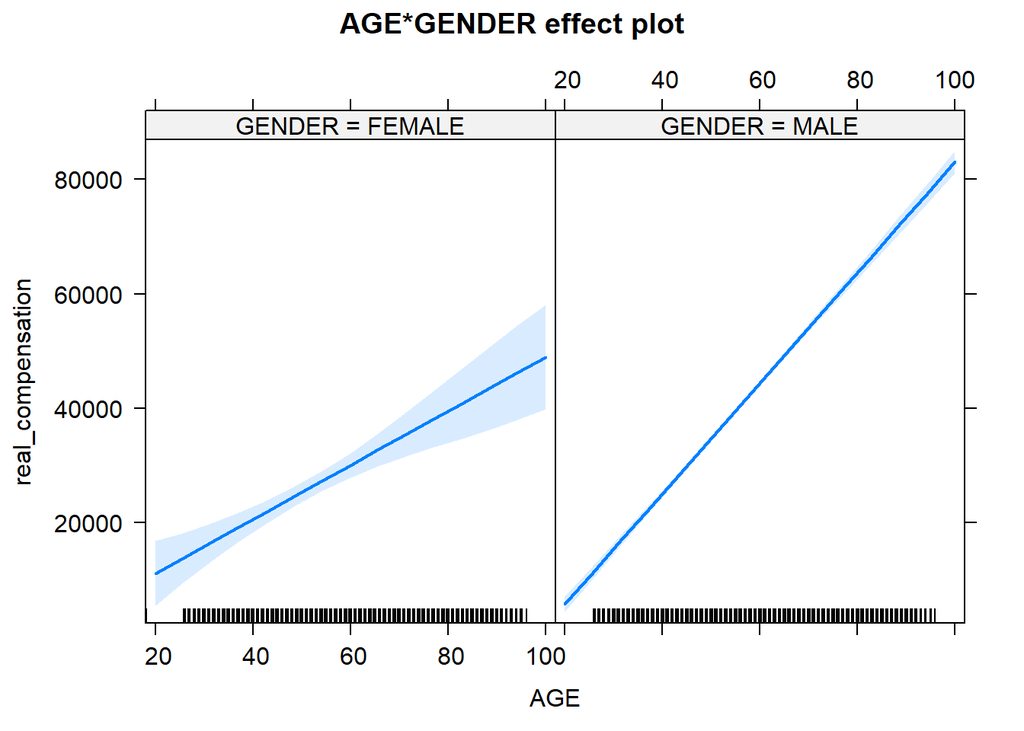

```r
modEffects = effect("AGE*GENDER", inter)

plot(modEffects)
```

*Discussion on interaction model:* We can see from the summary statistics of the interaction model that the interaction between AGE and GENDER is very influential on predicting the value of the compensation. Hence, we can say that these two variables are working together to predict the real compensation value rather than functioning on a standalone basis.

## Robust Analyses

You will likely find some problems with your model (e.g., outliers and/or standard error issues).

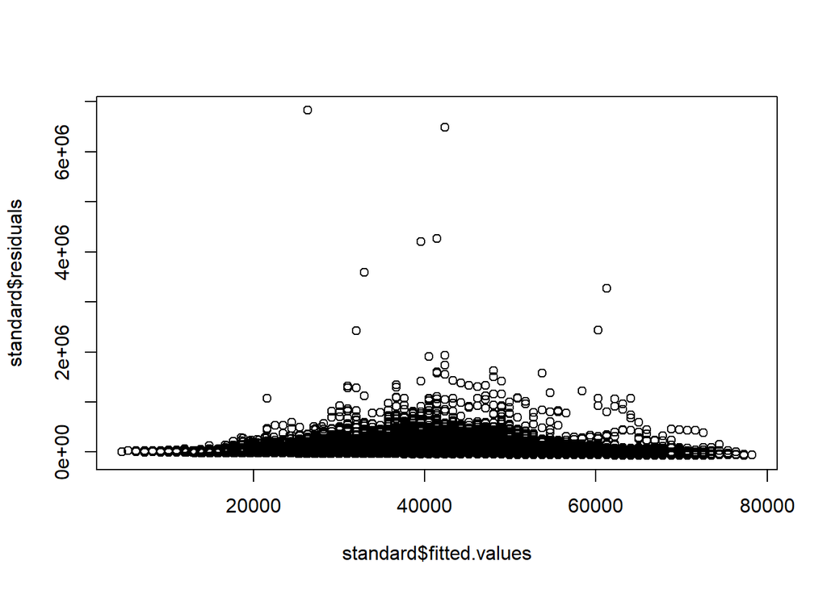

```r
plot(standard$fitted.values,standard$residuals)
```

```r
library(lmtest)
lmtest::bptest(standard)
```

```
##
##  studentized Breusch-Pagan test
##
## data:  standard
## BP = 14.511, df = 2, p-value = 0.0007063
```

Both the graph and the bptest results tell us there is heteroscedasticity within our data. Use sandwich to get more reasonable estimates

```r
library(sandwich)
coeftest(standard, vcov = vcovHC)
```

```
##
## t test of coefficients:
##
##               Estimate Std. Error t value  Pr(>|t|)
## (Intercept) -21995.361   1259.392 -17.465 < 2.2e-16 ***
## AGE            943.587     24.599  38.358 < 2.2e-16 ***
## GENDERMALE    9635.669    297.308  32.410 < 2.2e-16 ***
## ---
## Signif. codes:  0 '***' 0.001 '**' 0.01 '*' 0.05 '.' 0.1 ' ' 1
```

We may want to construct a robust linear model that adjusts the weight of the outliers.

```r
library('MASS')
robTest = rlm(real_compensation ~ AGE*GENDER, data = compen_selected, psi = psi.bisquare)
summary(robTest)
```

```
##
## Call: rlm(formula = real_compensation ~ AGE * GENDER, data = compen_selected,
##     psi = psi.bisquare)
## Residuals:
##     Min      1Q  Median      3Q     Max
##  -37347   -8690   -1049   14537 6832965
##
## Coefficients:
##                Value     Std. Error t value
## (Intercept)    4771.2294 1184.2541     4.0289
## AGE             319.3356   23.3655    13.6670
## GENDERMALE      329.6260 1214.8922     0.2713
## AGE:GENDERMALE   56.3602   23.9070     2.3575
##
## Residual standard error: 14900 on 159348 degrees of freedom
##   (106855 observations deleted due to missingness)
```